# Vida Útil de Biotêxteis

Geotêxteis e Soluções baseadas na Natureza

Prof. Dr. Luiz Diego Vidal Santos

## Visão Geral

### Tópicos Principais

- 1 Biotêxteis: definição, tipos e materiais
- 2 Mecanismos de degradação de fibras naturais
- 3 Fatores climáticos: tropical vs. temperado
- 4 Modelos de perda de resistência ao longo do tempo
- 5 Tabela comparativa de vida útil
- 6 Dimensionamento com previsão de degradação

**Objetivo Central**

Compreender os mecanismos de degradação de biotêxteis fabricados com fibras naturais, comparar taxas de degradação sob climas tropical e temperado, e aplicar modelos preditivos simples no dimensionamento de soluções baseadas na natureza.

# O QUE SÃO BIOTÊXTEIS?

## Definição e tipos

### Definição

**Biotêxteis** (ou geotêxteis biodegradáveis) são mantas, telas ou tecidos fabricados com **fibras naturais** utilizados para controle de erosão, proteção de taludes e restauração de solos.

### Principais fibras

| Fibra | Origem | Resistência à tração (MPa) |
| --- | --- | --- |
| Juta | Caule (*Corchorus*) | 393 - 773 |
| Coco (coir) | Mesocarpo do fruto | 131 - 175 |
| Taboa (*Typha*) | Folhas | 80 - 150 |
| Sisal | Folhas (*Agave*) | 511 - 635 |
| Rami | Caule (*Boehmeria*) | 400 - 938 |

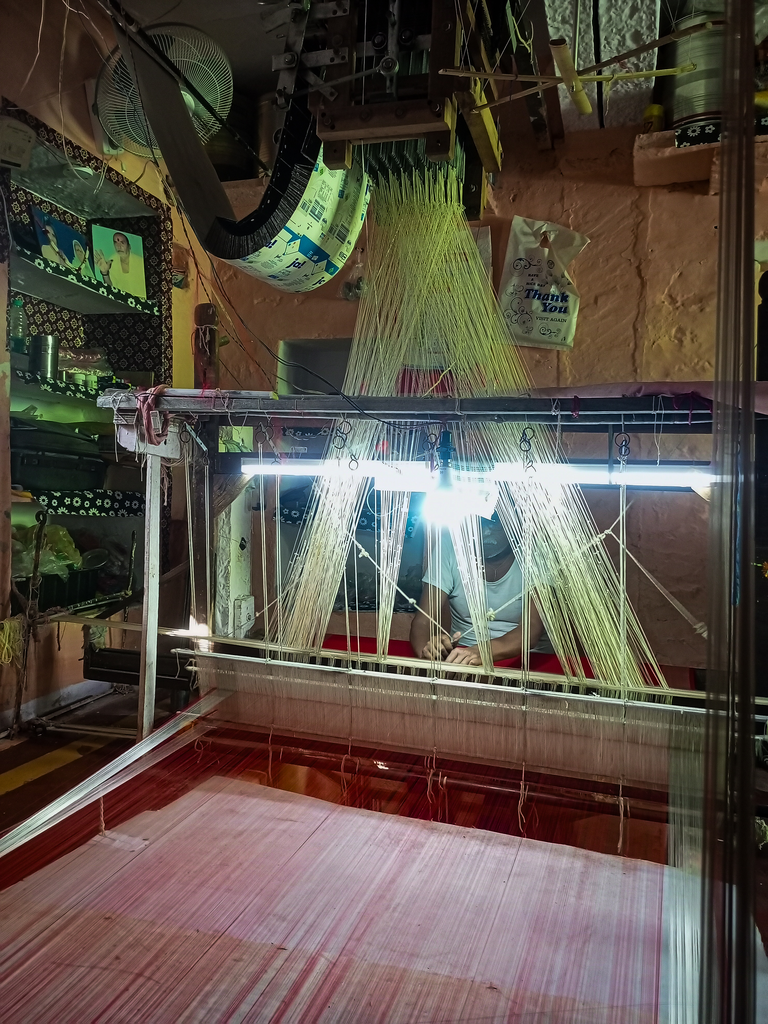

Tear artesanal para confecção de biotêxteis com fibras naturais

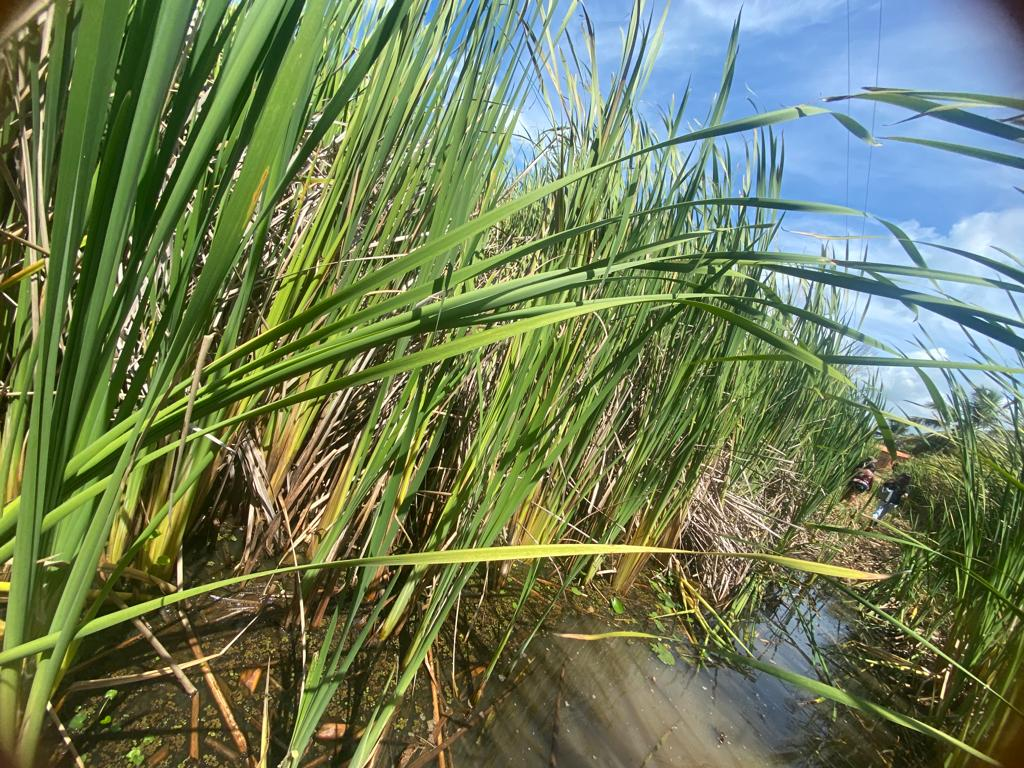

Fibra de junco - matéria-prima para geotêxteis biodegradáveis

| Critério | Sintético (PP/PET) | Biotêxtil |
| --- | --- | --- |
| Vida útil | 50-100+ anos | 1-5 anos |
| Biodegradação | Não | Sim |
| Custo | Alto | Baixo-Moderado |
| Impacto ambiental | Microplásticos | Nenhum |
| Incorporação de matéria orgânica | Não | Sim |

## Quando usar biotêxteis?

A escolha por biotêxteis é adequada quando:

1. **A vegetação se estabelece em 1-3 anos** - o biotêxtil protege o solo até a cobertura vegetal assumir
2. **O impacto ambiental é relevante** - áreas de preservação, margens de rios, APPs
3. **Disponibilidade local de fibras** - reduz custo e gera renda para comunidades
4. **O projeto é temporário** - taludes de construção civil, estradas rurais

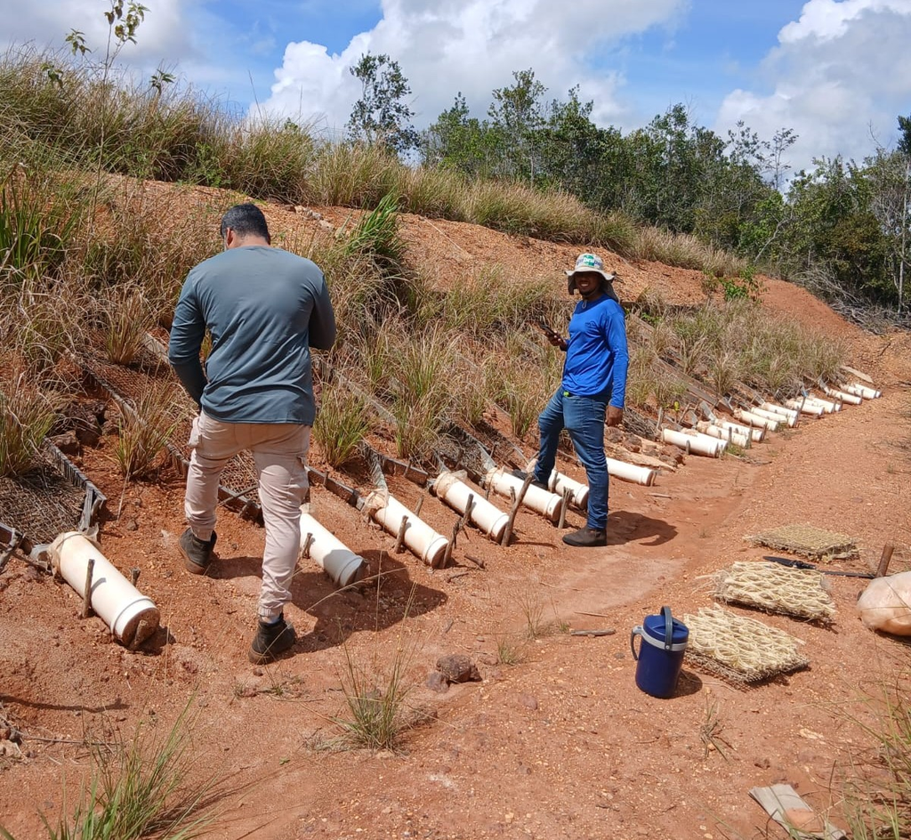

Talude protegido com biotêxtil em campo

**Conceito-chave:** o biotêxtil deve manter resistência funcional mínima **até que a vegetação feche o solo**. Degradação prematura = exposição do solo. Degradação lenta demais = impede o enraizamento.

# MECANISMOS DE DEGRADAÇÃO

## Processos de degradação

### Biodegradação

- **Fungos** (celulolíticos) e **bactérias** decompõem celulose e lignina
- Velocidade depende de: umidade, temperatura, pH, teor de lignina da fibra
- Fibras com **alta lignina** (coco) resistem mais que fibras celulósicas puras (juta)

### Fotodegradação

- Radiação UV quebra ligações moleculares
- Mais intensa em **fibras expostas** (sem contato com solo)
- Relevante nos primeiros meses antes da cobertura por sedimento

[figure not shown]

Câmara de degradação para ensaios de biotêxteis

### Degradação hidrolítica

- Ciclos de umedecimento/secamento causam **fadiga mecânica**
- Inchamento diferencial das fibras → microfissuras
- Mais intenso em climas com **alta amplitude hídrica**

### Degradação mecânica

- Abrasão por partículas de solo em escoamento
- Ataque por fauna do solo (cupins, formigas)
- Pisoteio animal em áreas de pastagem

**Na prática**, a degradação é **sinérgica** - todos os mecanismos atuam simultaneamente.

# CLIMA TROPICAL VS. TEMPERADO

## Comparação de condições

| Fator | Clima Tropical (Semiárido/Úmido) | Clima Temperado |
| --- | --- | --- |
| Temperatura média | 22-28 °C | 8-15 °C |
| Umidade do solo | Alta (variável) | Moderada (estável) |
| Radiação UV | Intensa (todo o ano) | Moderada (sazonal) |
| Atividade microbiana | Muito alta | Moderada-baixa |
| Ciclos umedecimento/secamento | Frequentes (tropical úmido) | Menos frequentes |
| Pluviosidade | 800-2000 mm/ano | 400-1000 mm/ano |

**Consequência:** biotêxteis no **Brasil** degradam **2 a 4× mais rápido** que os mesmos materiais testados na Europa. Dados europeus **não podem ser aplicados diretamente** ao dimensionamento nacional.

## Dados experimentais comparativos

### Perda de resistência à tração ao longo do tempo (% da resistência original)

| Meses | Juta (Tropical) | Juta (Temperado) | Coco (Tropical) | Coco (Temperado) |
| --- | --- | --- | --- | --- |
| 0 | 100% | 100% | 100% | 100% |
| 3 | 65% | 88% | 90% | 96% |
| 6 | 35% | 72% | 78% | 90% |
| 12 | 10% | 45% | 55% | 78% |
| 18 | ~0% | 25% | 35% | 62% |
| 24 | - | 10% | 20% | 48% |
| 36 | - | ~0% | 8% | 30% |

**Fonte:** adaptado de Sarsby (2007), Smets et al. (2011), Santos et al. (2023).

# MODELOS DE DEGRADAÇÃO

## Modelo exponencial simples

O modelo mais utilizado para descrever a perda de resistência é o **decaimento exponencial**:

$$R(t) = R_0 \times e^{-k \times t}$$

Onde:

- $R(t)$ = resistência no tempo $t$ (kN/m)
- $R_0$ = resistência inicial (kN/m)
- $k$ = constante de degradação (mês⁻¹)
- $t$ = tempo (meses)

### Meia-vida

$$t_{1/2} = \frac{\ln 2}{k} = \frac{0{,}693}{k}$$

**Valores típicos de $k$**

| Fibra | $k$ (tropical) | $k$ (temperado) |
| --- | --- | --- |
| Juta | 0,19 | 0,08 |
| Coco | 0,07 | 0,03 |
| Taboa | 0,12 | 0,05 |
| Sisal | 0,15 | 0,06 |

**Unidade:** mês⁻¹

**Exemplo:** Juta tropical, $t_{1/2} = 0{,}693 / 0{,}19 \approx 3{,}6$ meses

## Exercício de dimensionamento

### Problema

Um talude revegetado no interior da Bahia precisa de proteção por **12 meses** até o capim-vetiver cobrir o solo. O biotêxtil escolhido é de **fibra de coco** ($R_0 = 15$ kN/m). A resistência mínima funcional é **3 kN/m**.

### Solução

$$R(12) = 15 \times e^{-0{,}07 \times 12} = 15 \times e^{-0{,}84} = 15 \times 0{,}432 = 6{,}5 \; \text{kN/m}$$

$R(12) = 6{,}5$ kN/m > $R_{min} = 3$ kN/m

**O biotêxtil de coco atende ao requisito.**

Se fosse **juta** sob o mesmo clima:

$R(12) = 15 \times e^{-0{,}19 \times 12} = 15 \times 0{,}10 = 1{,}5$ kN/m

**Não atenderia.** Juta é indicada apenas para proteção de curto prazo (< 6 meses) em clima tropical.

# APLICAÇÃO PRÁTICA

## Planilha de cálculo preditivo

### Estrutura da planilha (Excel/Calc)

| Coluna | Conteúdo |
| --- | --- |
| A | Tempo (meses): 0, 1, 2, …, 36 |
| B | R₀ (kN/m) - resistência inicial |
| C | k - constante de degradação |
| D | R(t) = B2 × EXP(-C2 × A2) |
| E | R_min (kN/m) - limite funcional |
| F | Verificação: SE(D2 > E2; “OK”; “FALHA”) |

### Gráfico

Plotar D (R(t)) × A (meses), com linha horizontal em R_min.

O cruzamento indica a **vida útil funcional** do biotêxtil.

**Fórmula no Excel**

```
=B2*EXP(-C2*A2)
```

Para a meia-vida:

```
=LN(2)/C2
```

Para a vida útil funcional:

```
=-LN(E2/B2)/C2
```

(meses até atingir R_min)

## Exercício proposto

### Atividade

1. Monte a planilha no Excel com os valores de $k$ para juta, coco, taboa e sisal (clima tropical)
2. Considere $R_0 = 20$ kN/m e $R_{min} = 4$ kN/m
3. Calcule a vida útil funcional de cada fibra
4. Gere o gráfico de degradação comparativo
5. Para cada fibra, indique cenários de aplicação adequados (ex.: “coco → taludes com revegetação em 12-18 meses”)
6. Repita para clima temperado e compare os resultados

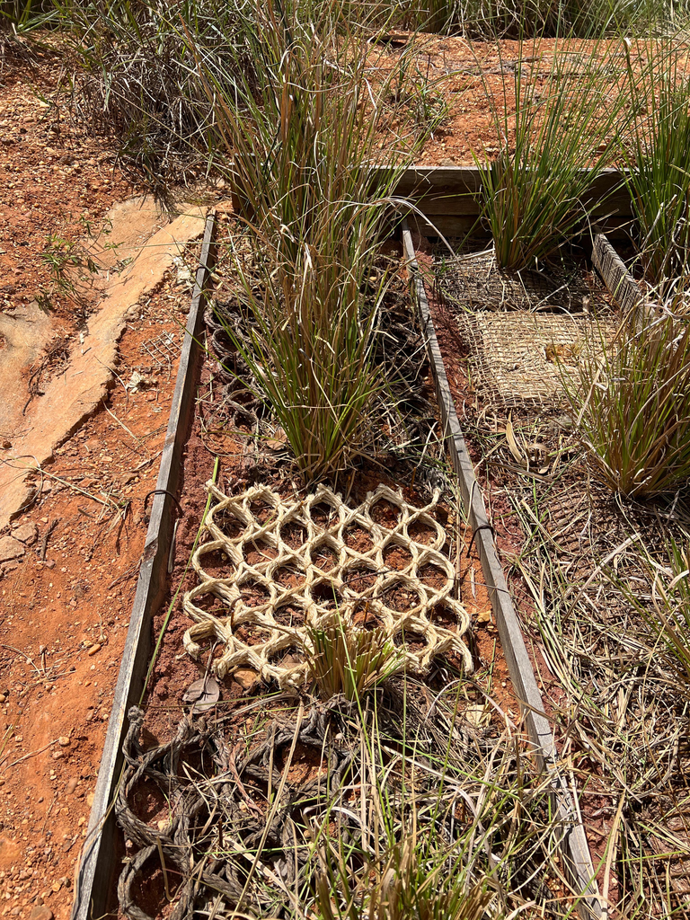

Coleta de amostras de biotêxtil em campo

[figure not shown]

Máquina universal de ensaio de tração

## Exercício - Entrega

**Entrega**

- **Formato:** planilha Excel (.xlsx) com gráficos
- **Prazo:** 7 dias
- **Critérios:** cálculos corretos, gráficos profissionais, indicação de cenários justificada

## Referências

- Sarsby, R. W. (2007). Use of limited life geotextiles (LLGs) for basal reinforcement of embankments. *Geosynthetics Int.*, 14(6), 355-368.
- Smets, T. et al. (2011). The importance of geotextile characteristics on erosion reduction. *Soil Technology*, 24(1), 69-80.
- Santos, L. D. V. et al. (2023). Vida útil de geotêxteis de taboa (*Typha*). *Engenharia Sanitária e Ambiental*.
- Lekha, K. R. (2004). Field instrumentation and monitoring of soil erosion in coir geotextile stabilised slopes. *Geotextiles and Geomembranes*, 22(5), 399-413.
- ABNT NBR ISO 10318:2013 - Geossintéticos - Termos e definições.

Obrigado!

Luiz Diego Vidal Santos

Universidade Estadual de Feira de Santana (UEFS)